# Self-Targeted Isoform Changes - RD7

Mervin M Fansler

18 November 2022

# Purpose

Does repression of transcriptional activity via CRISPR interference have a non-uniform effect on isoform abundances of the targeted gene? In this document, we consider all targeted perturbations for genes with multiple isoforms. If a common bias against isoforms in particular positions (e.g., IPA, short, long) is present, then this should be detectable with a statistic aggregated across all the targeted multi-UTR genes.

We can adopt the null hypothesis that isoform usage does not change in any specific way, namely, that any such statistics should not deviate significantly from similar ones comupted in any non-targeting “perturbations”.

# Initialization

## Libraries

```r
library(magrittr)
library(tidyverse)
library(ggbeeswarm)
library(plotly)
library(Matrix)
library(sparseMatrixStats)
library(SingleCellExperiment)
```

## Parameters

```r
set.seed(20220901)
MIN_UMIS=1000
N_EXAMPLE_PLOTS=25
FILE_SE_TX="data/se/rd7_essential_bulk_expressed.Rds"
```

# Data

## Loading

```r
se_tx_target <- readRDS(FILE_SE_TX)
```

## Preprocessing

### Identify Targeted Multi-UTR Genes

```r
gene_targets <- se_tx_target$target_gene_id %>%
    unique %>%
    `[`(str_detect(., "^ENSG"))

df_sampled <- rowData(se_tx_target) %>%
    as_tibble %>%
    mutate(ensembl_id=str_remove(gene_id, "\\.[0-9]+$")) %>%
    filter(ensembl_id %in% gene_targets)

cts_tx_target <- assay(se_tx_target, "counts")

df_multi <- df_sampled %>%
    filter(utr_type_raw == 'multi') %>%
    ## only consider expressed isoforms
    filter(rowSums(cts_tx_target[transcript_id,]) >= MIN_UMIS) %>%
    group_by(ensembl_id) %>%
    ## must have multiple expressed isoforms
    filter(dplyr::n() > 1) %>%
    ## recompute utr rank
    mutate(utr_rank_expr=rank(utr_rank),
           utr_wt=(utr_rank_expr - 1)/(max(utr_rank_expr) - 1)) %>%
    ungroup() %>%
    select(transcript_id, transcript_name, gene_id, gene_name, ensembl_id,
           utr_rank, utr_rank_expr, utr_wt)

idx_tx <- df_multi$transcript_id

df_multi %>% distinct(ensembl_id) %>% nrow %>%
    sprintf(fmt="Found %d targeted multi-UTR genes.")
```

```
## [1] "Found 1487 targeted multi-UTR genes."
```

```r
df_multi %>% nrow %>%
    sprintf(fmt="These consist of %d 3' UTR isoforms.")
```

```
## [1] "These consist of 4575 3' UTR isoforms."
```

### Missing Readouts

Are there any genes that are targeted, but are not identified via ENSEMBL IDs as being measured in the feature set?

```r
colData(se_tx_target) %>% as_tibble %>%
    filter(target_gene_id %in% gene_targets[!(gene_targets %in% df_sampled$ensembl_id)]) %>%
    distinct(target_gene, target_gene_id, sgID_AB) %>%
    knitr::kable()
```

| target_gene | target_gene_id | sgID_AB |
| --- | --- | --- |
| ALG1L | ENSG00000189366 | ALG1L_-*125655482.23-ENST00000340333.3\|ALG1L*-_125655452.23-ENST00000340333.3 |
| C14orf178 | ENSG00000197734 | C14orf178_+*78227426.23-P1P2\|C14orf178*+_78227476.23-P1P2 |
| CASP8AP2 | ENSG00000118412 | CASP8AP2_-*90539614.23-P1P2\|CASP8AP2*-_90539622.23-P1P2 |
| CBLN1 | ENSG00000102924 | CBLN1_+*49315691.23-P1P2\|CBLN1*+_49315694.23-P1P2 |
| CCDC144NL | ENSG00000205212 | CCDC144NL_-*20799255.23-P2\|CCDC144NL*+_20799243.23-P2 |
| CCDC144NL | ENSG00000205212 | CCDC144NL_+*20771514.23-P1\|CCDC144NL*+_20771332.23-P1 |
| CT45A5 | ENSG00000228836 | CT45A5_-*134975513.23-P1P2\|CT45A5*-_134975351.23-P1P2 |
| CYP2A13 | ENSG00000197838 | CYP2A13_-*41594703.23-P1P2\|CYP2A13*+_41594737.23-P1P2 |
| F8A1 | ENSG00000277203 | F8A1_-*154114513.23-P1P2\|F8A1*+_154114503.23-P1P2 |
| GATA1 | ENSG00000102145 | GATA1_-*48645022.23-P1P2\|GATA1*+_48644988.23-P1P2 |
| GOLGA6L1 | ENSG00000273976 | GOLGA6L1_+*22736912.23-ENST00000560659.2\|GOLGA6L1*+_22736950.23-ENST00000560659.2 |
| HIST2H2AA3 | ENSG00000203812 | HIST2H2AA3_+*149814282.23-ENST00000369161.3\|HIST2H2AA3*-_149814302.23-ENST00000369161.3 |
| HIST2H3A | ENSG00000203852 | HIST2H3A_+*149824198.23-P1P2\|HIST2H3A*+_149824178.23-P1P2 |
| HOXC10 | ENSG00000180818 | HOXC10_+*54379003.23-P1P2\|HOXC10*+_54379000.23-P1P2 |
| KCNA10 | ENSG00000143105 | KCNA10_-*111061735.23-ENST00000369771.2\|KCNA10*+_111061723.23-ENST00000369771.2 |
| MYO1H | ENSG00000174527 | MYO1H_-*109826559.23-ENST00000431443.2\|MYO1H*+_109826602.23-ENST00000431443.2 |
| OR2T29 | ENSG00000182783 | OR2T29_+*248722733.23-ENST00000328570.3\|OR2T29*-_248722384.23-ENST00000328570.3 |
| OR2T5 | ENSG00000203661 | OR2T5_-*248651931.23-ENST00000366473.2\|OR2T5*+_248651939.23-ENST00000366473.2 |
| OR4K1 | ENSG00000155249 | OR4K1_-*20403828.23-ENST00000285600.4\|OR4K1*+_20404057.23-ENST00000285600.4 |
| OR7A10 | ENSG00000127515 | OR7A10_+*14952616.23-ENST00000248058.1\|OR7A10*+_14952334.23-ENST00000248058.1 |
| OR7A17 | ENSG00000185385 | OR7A17_-*14992230.23-ENST00000327462.2\|OR7A17*+_14992143.23-ENST00000327462.2 |
| RGPD6 | ENSG00000183054 | RGPD6_+*111334472.23-ENST00000329516.3\|RGPD6*+_111334479.23-ENST00000329516.3 |
| SPDYE2 | ENSG00000205238 | SPDYE2_-*102196628.23-ENST00000341656.4\|SPDYE2*+_102196618.23-ENST00000341656.4 |
| SPDYE2 | ENSG00000205238 | SPDYE2_+*102191744.23-ENST00000432940.1-ENST00000507918.1\|SPDYE2*+_102191690.23-ENST00000432940.1-ENST00000507918.1 |
| SSX4 | ENSG00000268009 | SSX4_-*48242891.23-ENST00000376886.2\|SSX4*-_48242899.23-ENST00000376886.2 |
| TBC1D3 | ENSG00000274611 | TBC1D3_-*36357859.23-ENST00000537432.1\|TBC1D3*-_36357846.23-ENST00000537432.1 |
| TBCE | ENSG00000285053 | TBCE_-*235530783.23-P1P2\|TBCE*+_235530696.23-P1P2 |
| TRIM49C | ENSG00000204449 | TRIM49C_-*89764362.23-ENST00000432771.1-ENST00000448984.1\|TRIM49C*+_89764400.23-ENST00000432771.1-ENST00000448984.1 |
| U2AF1 | ENSG00000160201 | U2AF1_+*44527641.23-P1P2\|U2AF1*+_44527626.23-P1P2 |

Yes, a handful.

### Compute average WUI for non-targeting samples

The weighted usage index (WUI) is computed by assigning the expressed isoforms a rank based on cleavage position, $1..n$, where 1 is the most proximal and $n$ the most distal. Each position, is then evenly distributed on the closed unit interval. For example, a gene with three isoforms would have isoform weights of 0.0, 0.5, and 1.0. These weights are then multiplied by the respective usage ratios for each isoform in the gene. The set of weighted usage index values are then averaged across the set of considered genes.

In the following, we compute this statistic for each of the non-targeting samples.

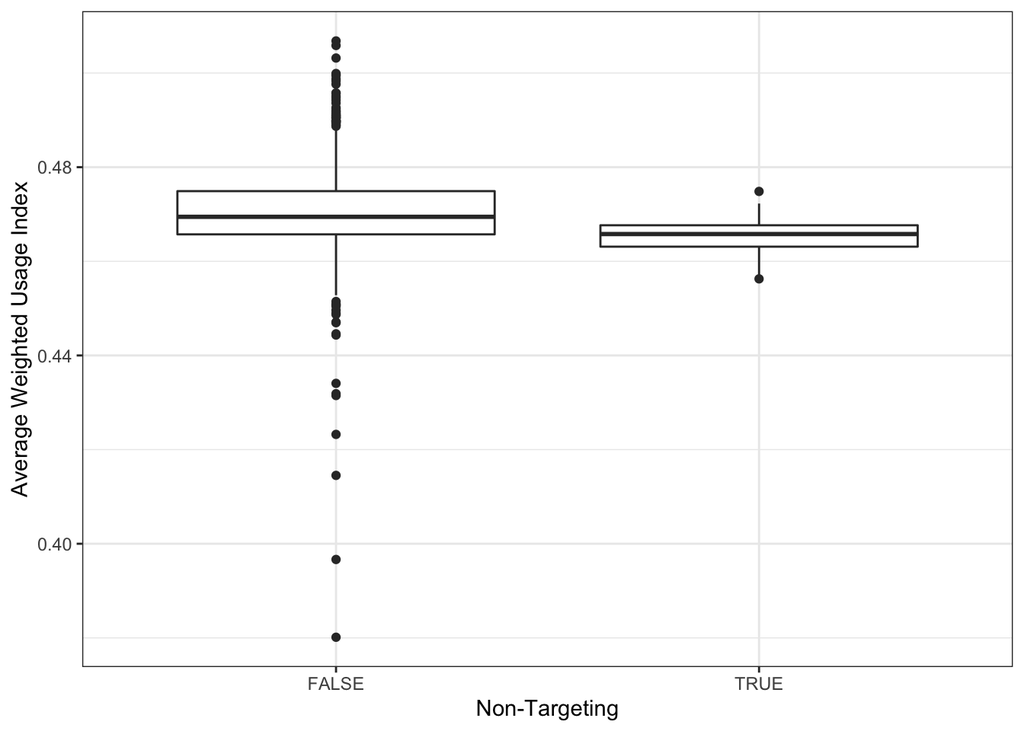

```r
wt_tx <- df_multi %>% dplyr::select(transcript_id, utr_wt) %>% deframe

M_gene_tx <- df_multi$ensembl_id %>% fac2sparse

cts_gene_target <- M_gene_tx %*% cts_tx_target[idx_tx,]
ui_tx_target <- cts_tx_target[idx_tx,] / (t(M_gene_tx) %*% cts_gene_target)
#ui_tx_target[is.na(ui_tx_target)] <- 0

wui_gene_target <- M_gene_tx %*% Diagonal(length(wt_tx), wt_tx) %*% ui_tx_target

idx_nt <- str_detect(colnames(ui_tx_target), fixed("non-targeting"))

awui_all <- colMeans(wui_gene_target, na.rm=TRUE)

df_awui <- enframe(awui_all, name="sgID_AB", value="awui") %>%
    mutate(is_nt=str_detect(sgID_AB, fixed("non-targeting")))

df_awui %>%
    ggplot(aes(x=is_nt, y=awui)) +
    geom_boxplot() +
    scale_y_continuous() +
    theme_bw() +
    labs(x="Non-Targeting", y="Average Weighted Usage Index")
```

### Compute composite average WUI across self-targets

For each perturbation targeting a multi-UTR gene, we compute the WUI for the targeted gene. When multiple perturbnations target the same gene, we take the mean for that gene. These per-gene WUI values are then averaged to yield an average WUI composited from usage indices across the various perturbations.

```r
ens_gene <- rownames(wui_gene_target) %>% set_names(.)

ens_target <- colData(se_tx_target) %>% as_tibble %>%
    select(sgID_AB, target_gene_id) %>% distinct %>%
    deframe %>% `[`(colnames(wui_gene_target))

I_gene_target <- outer(ens_gene, ens_target, "==") %>% as("lgTMatrix")

awui_self <- wui_gene_target[cbind(I_gene_target@i+1, I_gene_target@j+1)] %>%
    `names<-`(ens_gene[I_gene_target@i+1]) %>%
    enframe(name="gene", value="wui") %>%
    filter(!is.na(wui)) %>%
    group_by(gene) %>%
    summarize(wui=mean(wui)) %$%
    mean(wui)

#awui_self <- as.numeric(wt_tx %*% (rowSums(ui_tx_target * I_tx_target) / rowSums(I_tx_target)) / n_genes)

df_awui %<>% add_row(sgID_AB="self-targeting composite", awui=awui_self, is_nt=FALSE)
```

# Analysis

## AWUI Distribution

### Non-Targets vs Composite

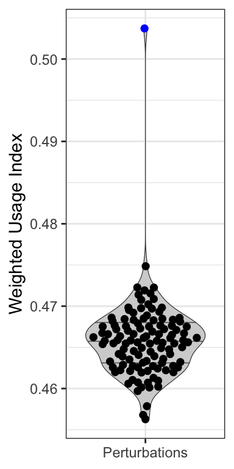

```r
df_awui %>%
    filter(str_detect(sgID_AB, "targeting")) %>%
        ggplot(aes(x="Perturbations", y=awui)) +
    geom_violin(fill='lightgrey', size=0.2, draw_quantiles=c(0.25, 0.50, 0.75)) +
    geom_quasirandom(aes(color=is_nt), pch=16, size=2) +
    scale_color_manual(values=c("blue", "black"), guide='none') +
    theme_bw() +
    labs(x=NULL, y="Weighted Usage Index")
```

### t-Test

Assuming normality and homoskedasticity, we can use a t-test to test whether the average weighted usage index for the composite is consistent with the distribution of values from the non-targeting cases.

```r
t.test(filter(df_awui, is_nt)$awui,
       filter(df_awui, sgID_AB == "self-targeting composite")$awui,
       var.equal=TRUE)
```

```
##
##  Two Sample t-test
##
## data:  filter(df_awui, is_nt)$awui and filter(df_awui, sgID_AB == "self-targeting composite")$awui
## t = -11.118, df = 112, p-value < 2.2e-16
## alternative hypothesis: true difference in means is not equal to 0
## 95 percent confidence interval:
##  -0.04494268 -0.03134678
## sample estimates:
## mean of x mean of y
## 0.4655680 0.5037127
```

# Random Permutations

While this all appears significant, it is possible that something is happening globally to isoform usage in cells that have repressed transcription of essential genes. Since we are specifically interested in whether genes that are directly targeted show a pattern of isoform usage change, we can use a null distribution of artificial composites that randomly take the usage levels from targeting perturbations, but not limiting to the targeted gene.

## Compute AWUI for permuted composites

```r
idx_multi_target <- which(colSums(I_gene_target) > 0)

random_awui <- function () {
    I_gene_target_perm <- I_gene_target[,sample(idx_multi_target)]
    awui <- wui_gene_target[cbind(I_gene_target_perm@i+1, I_gene_target_perm@j+1)] %>%
        `names<-`(ens_gene[I_gene_target_perm@i+1]) %>%
        enframe(name="gene", value="wui") %>%
        filter(!is.na(wui)) %>%
        group_by(gene) %>%
        summarize(wui=mean(wui)) %$%
        mean(wui)
    as.numeric(awui)
}

df_perms <- tibble(mode="permutation", awui=replicate(1000, random_awui())) %>%
    add_row(mode="self-targeting", awui=awui_self)
```

## Permuted composites distribution

Does the composite AWUI for self-targeted genes look like it comes from the distribution of AWUIs from permuted composites?

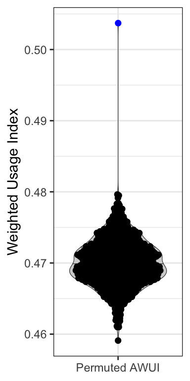

```r
df_perms %>%
    ggplot(aes(x="Permuted AWUI", y=awui)) +
    geom_violin(fill='lightgrey', size=0.2, draw_quantiles=c(0.25, 0.50, 0.75)) +
    geom_quasirandom(aes(color=mode), pch=16, size=2) +
    scale_color_manual(values=c("black", "blue"), guide='none') +
    theme_bw() +
    labs(x=NULL, y="Weighted Usage Index")
```

No, it again looks significantly higher

## t-Tests

### Test composite against permutations

```r
t.test(filter(df_perms, mode != 'self-targeting')$awui,
       filter(df_perms, mode == 'self-targeting')$awui,
       var.equal=TRUE)
```

```
##
##  Two Sample t-test
##
## data:  filter(df_perms, mode != "self-targeting")$awui and filter(df_perms, mode == "self-targeting")$awui
## t = -10.422, df = 999, p-value < 2.2e-16
## alternative hypothesis: true difference in means is not equal to 0
## 95 percent confidence interval:
##  -0.04001247 -0.02733190
## sample estimates:
## mean of x mean of y
## 0.4700406 0.5037127
```

Yes, significant.

### Test non-targeting versus permuted composites

```r
t.test(filter(df_awui, is_nt)$awui,
       filter(df_perms, mode != 'self-targeting')$awui)
```

```
##
##  Welch Two Sample t-test
##
## data:  filter(df_awui, is_nt)$awui and filter(df_perms, mode != "self-targeting")$awui
## t = -13.265, df = 135.61, p-value < 2.2e-16
## alternative hypothesis: true difference in means is not equal to 0
## 95 percent confidence interval:
##  -0.005139343 -0.003805748
## sample estimates:
## mean of x mean of y
## 0.4655680 0.4700406
```

Yes, but the effect size is an order of magnitude smaller.

# Individual Genes

## Example Plots

Let’s plot some random examples. The blue dot represents the WUI value for gene in the targeted case.

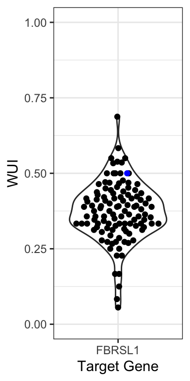

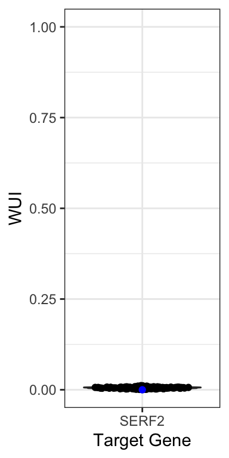

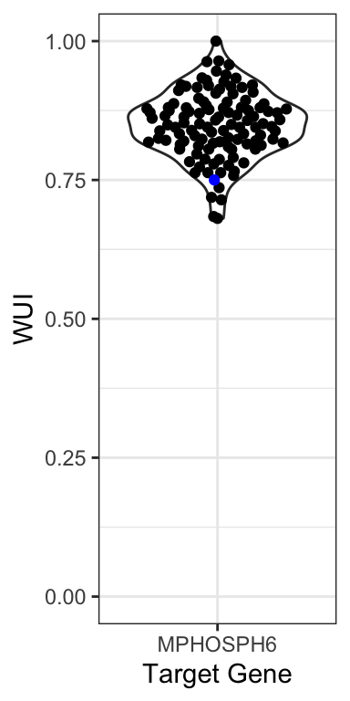

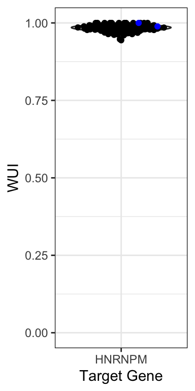

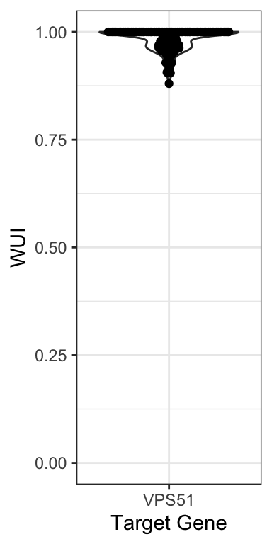

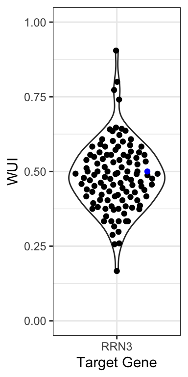

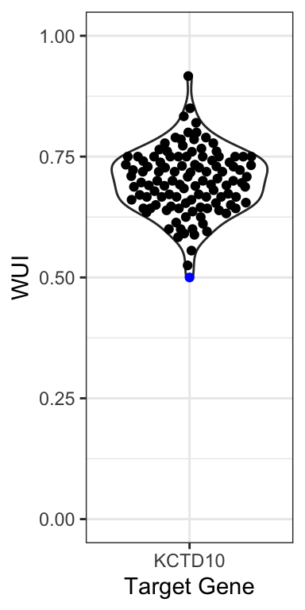

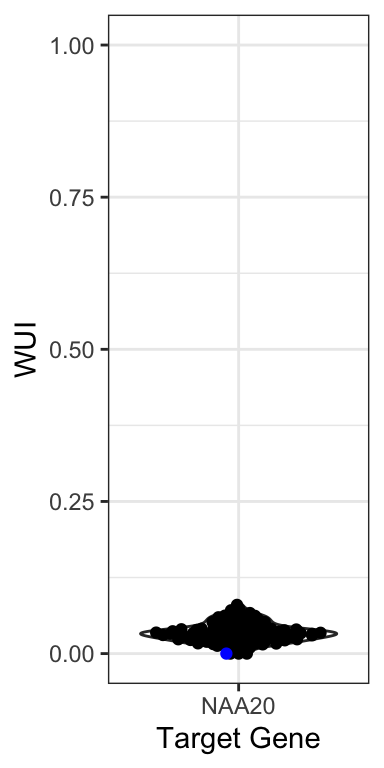

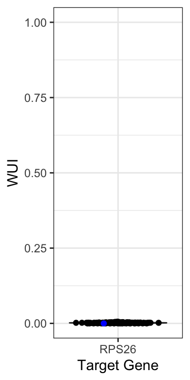

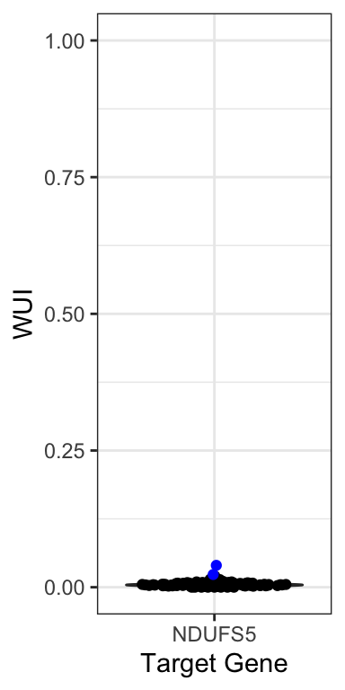

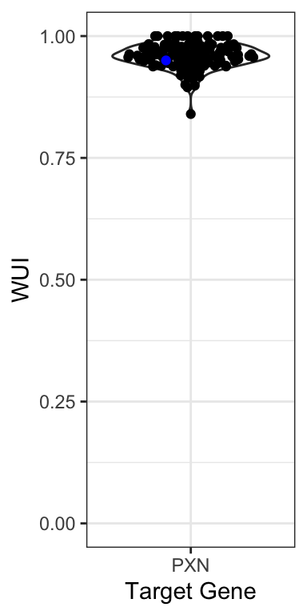

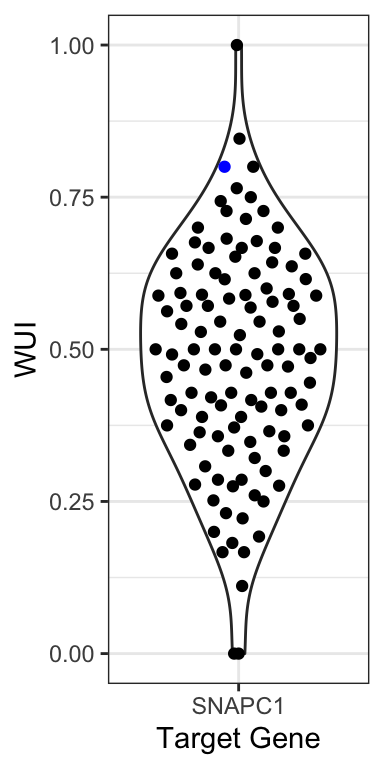

[13 more figures not shown]

```r
id2sym <- colData(se_tx_target) %>% as_tibble %>%
    select(target_gene_id, target_gene) %>% distinct %>%
    deframe()

for (i in sample.int(nrow(wui_gene_target), size=N_EXAMPLE_PLOTS)) {
    gene_label <- id2sym[rownames(wui_gene_target)[i]]
    idx_self <- which(I_gene_target[i,])
    print({
        tibble(target=colnames(wui_gene_target[,idx_nt]), wui=wui_gene_target[i,idx_nt]) %>%
            add_row(target="self-targeting", wui=wui_gene_target[i, idx_self]) %>%
            mutate(is_self_target=target == "self-targeting") %>%
            ggplot(aes(x=gene_label, y=wui)) +
            geom_violin() +
            geom_quasirandom(aes(color=is_self_target)) +
            scale_y_continuous(limits=c(0,1)) +
            scale_color_manual(values=c("black", "blue"), guide='none') +
            theme_bw() +
            labs(x="Target Gene", y="WUI")
    })
}
```

# Conclusion

There is a significant effect of lengthing in the average weighted usage index (WUI) of CRISPRi-targeted genes versus controls. The individual WUIs, however, do show a broad range of perturbations.

# Runtime Details

## Conda Environment

```
## Conda Environment YAML
name: base
channels:
  - conda-forge
  - bioconda
  - defaults
dependencies:
  - anaconda-client=1.8.0=pyhd8ed1ab_0
  - anaconda-project=0.10.2=pyhd8ed1ab_0
  - attrs=21.2.0=pyhd8ed1ab_0
  - awscli=1.25.79=py39h6e9494a_0
  - backports=1.0=py_2
  - backports.functools_lru_cache=1.6.4=pyhd8ed1ab_0
  - backports.zoneinfo=0.2.1=py39h701faf5_5
  - bagit=1.8.1=pyhd8ed1ab_0
  - bagit-profile=1.3.1=pyhd8ed1ab_0
  - bdbag=1.6.1=pyhd8ed1ab_0
  - beautifulsoup4=4.9.3=pyhb0f4dca_0
  - blinker=1.4=py_1
  - boa=0.13.0=pyha770c72_0
  - boolean.py=3.7=py_0
  - boto3=1.24.78=pyhd8ed1ab_0
  - botocore=1.27.78=pyhd8ed1ab_0
  - brotlipy=0.7.0=py39h63b48b0_1004
  - bzip2=1.0.8=h0d85af4_4
  - c-ares=1.18.1=h0d85af4_0
  - ca-certificates=2022.9.24=h033912b_0
  - cachecontrol=0.12.11=pyhd8ed1ab_0
  - cairo=1.16.0=he43a7df_1008
  - cctools=973.0.1=hd9211c8_2
  - cctools_osx-64=973.0.1=h3e07e27_2
  - certifi=2022.9.24=pyhd8ed1ab_0
  - cffi=1.15.1=py39hae9ecf2_0
  - chardet=5.0.0=py39h6e9494a_0
  - charset-normalizer=2.0.0=pyhd8ed1ab_0
  - click=8.1.3=py39h6e9494a_0
  - clyent=1.2.2=py_1
  - colorama=0.4.3=py_0
  - commonmark=0.9.1=py_0
  - conda=4.14.0=py39h6e9494a_0
```

[output cut: 174 more lines]

```
  - watchgod=0.7=pyhd8ed1ab_0
  - wcwidth=0.2.5=pyh9f0ad1d_2
  - wget=1.20.3=h52ee1ee_1
  - wheel=0.37.0=pyhd8ed1ab_1
  - wrapt=1.14.1=py39h701faf5_0
  - xxhash=0.8.0=h35c211d_3
  - xz=5.2.5=haf1e3a3_1
  - yaml=0.2.5=haf1e3a3_0
  - yaml-cpp=0.7.0=hb486fe8_1
  - zipp=3.5.0=pyhd8ed1ab_0
  - zlib=1.2.13=hfd90126_4
  - zstd=1.5.2=hfa58983_4
  - pip:
    - pyopenssl==20.0.1
prefix: /Users/mfansler/miniconda3
```